# Industry 4.0 의 중심, BigData

Data Processing Based Python @ [FB / jskim.kr](https://www.facebook.com/jskim.kr), [김진수](bigpycraft@gmail.com)

# NumPy Basics

> NumPy 는 'Numerical Python' 의 줄임말

> NumPy 제공 기능
> - 빠르고 메모리를 효율적으로 사용하며 벡터 산술연산과 세련된 브로드캐스팅 기능을 제공하는 다차원 배열인 ndarray
> - 반복문을 작성할 필요 없이 전체 데이터 배열에 대해 빠른 연산을 제공하는 표준 수학 함수
> - 배열 데이터를 디스크에 쓰거나 읽을 수 있는 도구와 메모리에 올려진 파일을 사용하는 도구
> - 선형대수, 난수발생기, 푸리에 변환 기능
> - C, C++, FORTRAN으로 쓰여진 코드를 통합하는 도구

```python
# NumPy Basics
from IPython.display import Image
```

### The NumPy ndarray: a multidimensional array object

> 다차원 배열 객체

```python
from numpy.random import randn
import numpy as np
```

```python
data = randn(2, 3)
data
```

```
array([[-0.74726055,  0.26449224, -0.62497113],
       [-0.74643578, -0.87689978, -0.96609261]])
```

```python
data * 10
```

```
array([[-7.47260546,  2.64492243, -6.24971127],
       [-7.46435778, -8.76899782, -9.66092611]])
```

```python
data + data
```

```
array([[-1.49452109,  0.52898449, -1.24994225],
       [-1.49287156, -1.75379956, -1.93218522]])
```

```python
data
```

```
array([[-0.74726055,  0.26449224, -0.62497113],
       [-0.74643578, -0.87689978, -0.96609261]])
```

```python
data.shape
```

```
(2, 3)
```

```python
data.dtype
```

```
dtype('float64')
```

### Creating ndarrays

```python
data1 = [6, 7.5, 8, 0, 1]
arr1 = np.array(data1)
arr1
```

```
array([6. , 7.5, 8. , 0. , 1. ])
```

```python
data2 = [[1, 2, 3, 4], [5, 6, 7, 8]]
arr2 = np.array(data2)
arr2
```

```
array([[1, 2, 3, 4],
       [5, 6, 7, 8]])
```

```python
arr2.ndim
```

```
2
```

```python
arr2.shape
```

```
(2, 4)
```

```python
arr1.dtype
```

```
dtype('float64')
```

```python
arr2.dtype
```

```
dtype('int32')
```

```python
np.zeros(10)
```

```
array([0., 0., 0., 0., 0., 0., 0., 0., 0., 0.])
```

```python
np.zeros((3, 6))
```

```
array([[0., 0., 0., 0., 0., 0.],
       [0., 0., 0., 0., 0., 0.],
       [0., 0., 0., 0., 0., 0.]])
```

```python
np.empty((2, 3, 2))
```

```
array([[[1.15235817e-311, 3.16202013e-322],
        [0.00000000e+000, 0.00000000e+000],
        [1.33511969e-306, 1.04829383e+165]],

       [[9.77558007e+165, 9.59551017e-071],
        [4.91337850e-062, 2.73886907e-057],
        [2.04164307e+184, 1.48711038e-076]]])
```

[Tip] np.empty  
np.empty는 0으로 초기화된 배열을 반환하지 않는다.  
대부분 empty는 초기화되지 않은 값으로 채워진 배열을 반환한다.

```python
np.arange(15)
```

```
array([ 0,  1,  2,  3,  4,  5,  6,  7,  8,  9, 10, 11, 12, 13, 14])
```

### Data Types for ndarrays

```python
arr1 = np.array([1, 2, 3], dtype=np.float64)
arr1.dtype
```

```
dtype('float64')
```

```python
arr2 = np.array([1, 2, 3], dtype=np.int32)
arr2.dtype
```

```
dtype('int32')
```

```python
arr = np.array([1, 2, 3, 4, 5])
arr.dtype
```

```
dtype('int32')
```

```python
float_arr = arr.astype(np.float64)
float_arr.dtype
```

```
dtype('float64')
```

```python
arr = np.array([3.7, -1.2, -2.6, 0.5, 12.9, 10.1])
arr
```

```
array([ 3.7, -1.2, -2.6,  0.5, 12.9, 10.1])
```

[Tip] astype  
astype을 호출하면 새로운 dtype이 이전 dtype과 같아도 항상 새로운 배열을 생성(데이터를 복사)한다.  
float64나 float32 같은 부동소수점은 근사값이라는 사실을 염두에 두는게 중요하다.

```python
# astype 을 사용하여 숫자로 변환
arr.astype(np.int32)
```

```
array([ 3, -1, -2,  0, 12, 10])
```

```python
numeric_strings = np.array(['1.25', '-9.6', '42'], dtype=np.string_)
numeric_strings.astype(float)
```

```
array([ 1.25, -9.6 , 42.  ])
```

```python
int_array = np.arange(10)
int_array
```

```
array([0, 1, 2, 3, 4, 5, 6, 7, 8, 9])
```

```python
calibers = np.array([.22, .270, .357, .380, .44, .50], dtype=np.float64)
calibers
```

```
array([0.22 , 0.27 , 0.357, 0.38 , 0.44 , 0.5  ])
```

```python
int_array.astype(calibers.dtype)
```

```
array([0., 1., 2., 3., 4., 5., 6., 7., 8., 9.])
```

```python
# u4는 uint32와 동일
empty_uint32 = np.empty(8, dtype='u4')
empty_uint32
```

```
array([         0, 1075314688,          0, 1075707904,          0,
       1075838976,          0, 1072693248], dtype=uint32)
```

### Operations between arrays and scalars

> 배열과 스칼라간의 연산

```python
arr = np.array([[1., 2., 3.], [4., 5., 6.]])
arr
```

```
array([[1., 2., 3.],
       [4., 5., 6.]])
```

```python
arr * arr
```

```
array([[ 1.,  4.,  9.],
       [16., 25., 36.]])
```

```python
arr - arr
```

```
array([[0., 0., 0.],
       [0., 0., 0.]])
```

```python
1 / arr
```

```
array([[1.        , 0.5       , 0.33333333],
       [0.25      , 0.2       , 0.16666667]])
```

```python
arr ** 0.5
```

```
array([[1.        , 1.41421356, 1.73205081],
       [2.        , 2.23606798, 2.44948974]])
```

### Basic indexing and slicing

> 색인과 슬라이싱 기초

```python
arr = np.arange(10)
arr
# arr[5]
# arr[5:8]
# arr[5:8] = 12
```

```
array([0, 1, 2, 3, 4, 5, 6, 7, 8, 9])
```

```python
arr[5]
```

```
5
```

```python
arr[5:8]
```

```
array([5, 6, 7])
```

```python
arr[5:8] = 12
```

```python
arr
```

```
array([ 0,  1,  2,  3,  4, 12, 12, 12,  8,  9])
```

```python
arr_slice = arr[5:8]
arr_slice
```

```
array([12, 12, 12])
```

```python
arr_slice[1] = 12345
arr
```

```
array([    0,     1,     2,     3,     4,    12, 12345,    12,     8,
           9])
```

```python
arr_slice[:] = 64
arr
```

```
array([ 0,  1,  2,  3,  4, 64, 64, 64,  8,  9])
```

[Tip] 슬라이스 복사본  
만약에 뷰 대신 ndarray 슬라이스의 복사본을 얻고 싶다면 arr[5:8].copy()를 사용해서 명시적으로 배열을 복사하면 된다.

### 2차원 배열

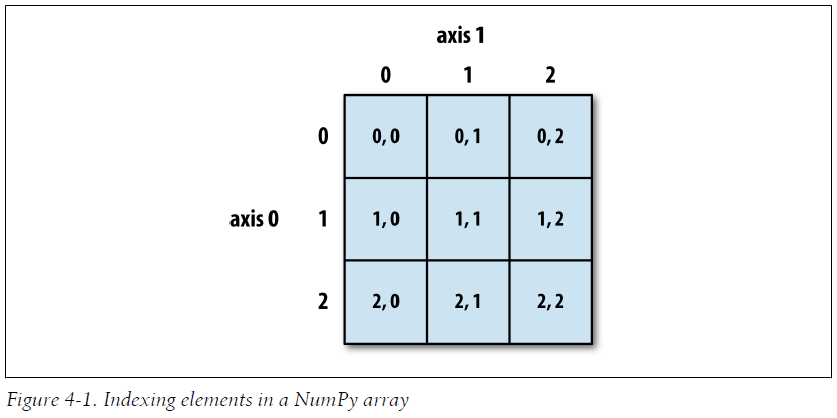

```python
# NumPy 배열에서 요소 색인하기
Image(bpc.Figure4_1)
```

```python
arr2d = np.array([[1, 2, 3], [4, 5, 6], [7, 8, 9]])
arr2d[2]
```

```
array([7, 8, 9])
```

```python
arr2d[0][2]
```

```
3
```

```python
arr2d[0, 2]
```

```
3
```

### 3차원 배열

```python
arr3d = np.array([[[1, 2, 3], [4, 5, 6]], [[7, 8, 9], [10, 11, 12]]])
arr3d
```

```
array([[[ 1,  2,  3],
        [ 4,  5,  6]],

       [[ 7,  8,  9],
        [10, 11, 12]]])
```

```python
arr3d[0]
```

```
array([[1, 2, 3],
       [4, 5, 6]])
```

```python
old_values = arr3d[0].copy()
old_values
```

```
array([[1, 2, 3],
       [4, 5, 6]])
```

```python
arr3d[0] = 42
arr3d
```

```
array([[[42, 42, 42],
        [42, 42, 42]],

       [[ 7,  8,  9],
        [10, 11, 12]]])
```

```python
arr3d[0] = old_values
arr3d
```

```
array([[[ 1,  2,  3],
        [ 4,  5,  6]],

       [[ 7,  8,  9],
        [10, 11, 12]]])
```

```python
arr3d[1, 0]
```

```
array([7, 8, 9])
```

### Indexing with slices

> 슬라이스 색인

```python
arr
```

```
array([ 0,  1,  2,  3,  4, 64, 64, 64,  8,  9])
```

```python
arr[1:6]
```

```
array([ 1,  2,  3,  4, 64])
```

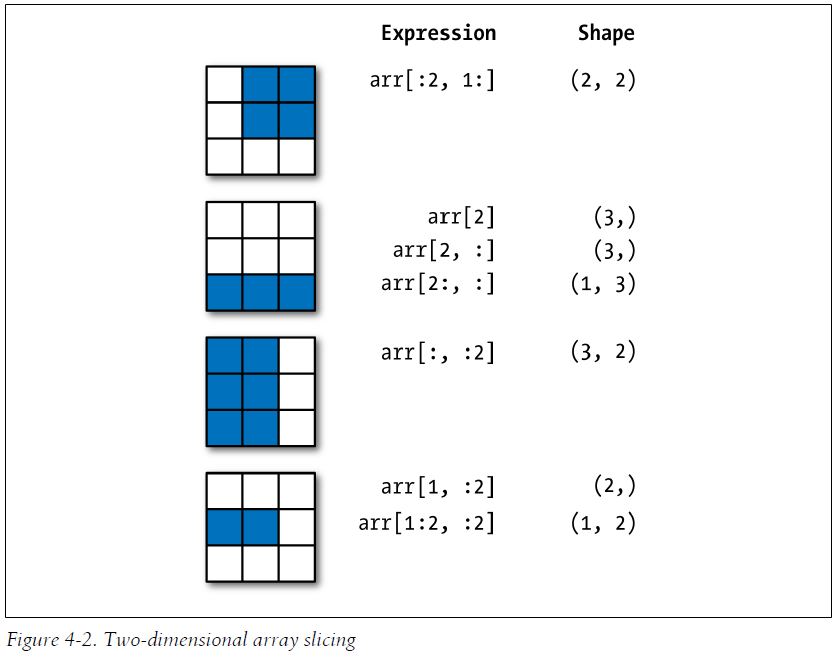

```python
# 2차원 배열 슬라이싱
Image(bpc.Figure4_2)
```

```python
arr2d
```

```
array([[1, 2, 3],
       [4, 5, 6],
       [7, 8, 9]])
```

```python
arr2d[:2]
```

```
array([[1, 2, 3],
       [4, 5, 6]])
```

```python
arr2d[:2, 1:]
```

```
array([[2, 3],
       [5, 6]])
```

```python
arr2d[1, :2]
```

```
array([4, 5])
```

```python
arr2d[2, :1]
```

```
array([7])
```

```python
arr2d[:, :1]
```

```
array([[1],
       [4],
       [7]])
```

```python
arr2d[:2, 1:] = 0
```

```python
arr2d
```

```
array([[1, 0, 0],
       [4, 0, 0],
       [7, 8, 9]])
```

### Boolean indexing

> 불리언 색인

```python
names = np.array(['Bob', 'Joe', 'Will', 'Bob', 'Will', 'Joe', 'Joe'])
names
```

```
array(['Bob', 'Joe', 'Will', 'Bob', 'Will', 'Joe', 'Joe'], dtype='<U4')
```

```python
data = randn(7, 4)
data
```

```
array([[-0.75336457,  1.5319453 ,  0.79576137,  0.61279488],
       [-0.20769947,  2.01122047, -0.37986782, -0.97632648],
       [ 1.14202885,  0.12517972,  1.34817308, -1.01143259],
       [ 0.28453211, -0.75163725,  0.13015273, -0.1955479 ],
       [-0.13762612, -1.42957618,  0.18496932, -2.66224946],
       [ 0.66828509, -2.31019228, -0.69126858, -1.95048141],
       [-0.75173771, -0.21093481,  0.27649681,  0.2007879 ]])
```

```python
names == 'Bob'
```

```
array([ True, False, False,  True, False, False, False])
```

```python
data[names == 'Bob']
```

```
array([[-0.75336457,  1.5319453 ,  0.79576137,  0.61279488],
       [ 0.28453211, -0.75163725,  0.13015273, -0.1955479 ]])
```

```python
data[names == 'Bob', 2:]
```

```
array([[ 0.79576137,  0.61279488],
       [ 0.13015273, -0.1955479 ]])
```

```python
data[names == 'Bob', 3]
```

```
array([ 0.61279488, -0.1955479 ])
```

```python
names != 'Bob'
```

```
array([False,  True,  True, False,  True,  True,  True])
```

```python
# data[-(names == 'Bob')]
data[~(names == 'Bob')]
```

```
array([[-0.20769947,  2.01122047, -0.37986782, -0.97632648],
       [ 1.14202885,  0.12517972,  1.34817308, -1.01143259],
       [-0.13762612, -1.42957618,  0.18496932, -2.66224946],
       [ 0.66828509, -2.31019228, -0.69126858, -1.95048141],
       [-0.75173771, -0.21093481,  0.27649681,  0.2007879 ]])
```

[Tip] NumPy Boolean Negative  
'-' 연산자는 사용하지 않으며, ~ 혹은 Logical Not 함수를 대신 사용한다.

```python
data[~(names == 'Bob')]
```

```
array([[-0.20769947,  2.01122047, -0.37986782, -0.97632648],
       [ 1.14202885,  0.12517972,  1.34817308, -1.01143259],
       [-0.13762612, -1.42957618,  0.18496932, -2.66224946],
       [ 0.66828509, -2.31019228, -0.69126858, -1.95048141],
       [-0.75173771, -0.21093481,  0.27649681,  0.2007879 ]])
```

```python
data[ (names != 'Bob')]
```

```
array([[-0.20769947,  2.01122047, -0.37986782, -0.97632648],
       [ 1.14202885,  0.12517972,  1.34817308, -1.01143259],
       [-0.13762612, -1.42957618,  0.18496932, -2.66224946],
       [ 0.66828509, -2.31019228, -0.69126858, -1.95048141],
       [-0.75173771, -0.21093481,  0.27649681,  0.2007879 ]])
```

```python
data
```

```
array([[-0.75336457,  1.5319453 ,  0.79576137,  0.61279488],
       [-0.20769947,  2.01122047, -0.37986782, -0.97632648],
       [ 1.14202885,  0.12517972,  1.34817308, -1.01143259],
       [ 0.28453211, -0.75163725,  0.13015273, -0.1955479 ],
       [-0.13762612, -1.42957618,  0.18496932, -2.66224946],
       [ 0.66828509, -2.31019228, -0.69126858, -1.95048141],
       [-0.75173771, -0.21093481,  0.27649681,  0.2007879 ]])
```

```python
mask = (names == 'Bob') | (names == 'Will')
mask
```

```
array([ True, False,  True,  True,  True, False, False])
```

```python
data[mask]
```

```
array([[-0.75336457,  1.5319453 ,  0.79576137,  0.61279488],
       [ 1.14202885,  0.12517972,  1.34817308, -1.01143259],
       [ 0.28453211, -0.75163725,  0.13015273, -0.1955479 ],
       [-0.13762612, -1.42957618,  0.18496932, -2.66224946]])
```

```python
data[data < 0] = 0
data
```

```
array([[0.        , 1.5319453 , 0.79576137, 0.61279488],
       [0.        , 2.01122047, 0.        , 0.        ],
       [1.14202885, 0.12517972, 1.34817308, 0.        ],
       [0.28453211, 0.        , 0.13015273, 0.        ],
       [0.        , 0.        , 0.18496932, 0.        ],
       [0.66828509, 0.        , 0.        , 0.        ],
       [0.        , 0.        , 0.27649681, 0.2007879 ]])
```

```python
data[names != 'Joe'] = 7
data
```

```
array([[7.        , 7.        , 7.        , 7.        ],
       [0.        , 2.01122047, 0.        , 0.        ],
       [7.        , 7.        , 7.        , 7.        ],
       [7.        , 7.        , 7.        , 7.        ],
       [7.        , 7.        , 7.        , 7.        ],
       [0.66828509, 0.        , 0.        , 0.        ],
       [0.        , 0.        , 0.27649681, 0.2007879 ]])
```

### Fancy indexing

> 팬시 색인
> - 팬시 색인은 정수 배열을 사용한 색인을 설명하기 위해 NumPy에서 차용한 단어다.

```python
arr = np.empty((8, 4))
for i in range(8):
    arr[i] = i
arr
```

```
array([[0., 0., 0., 0.],
       [1., 1., 1., 1.],
       [2., 2., 2., 2.],
       [3., 3., 3., 3.],
       [4., 4., 4., 4.],
       [5., 5., 5., 5.],
       [6., 6., 6., 6.],
       [7., 7., 7., 7.]])
```

> - 특정한 순서로 로우를 선택하고 싶다면, 그냥 원하는 순서가 명시된 정수가 담긴 ndarray나 리스트를 넘기면 된다.

```python
arr[[4, 3, 0, 6]]
```

```
array([[4., 4., 4., 4.],
       [3., 3., 3., 3.],
       [0., 0., 0., 0.],
       [6., 6., 6., 6.]])
```

```python
arr[[-3, -5, -7]]
```

```
array([[5., 5., 5., 5.],
       [3., 3., 3., 3.],
       [1., 1., 1., 1.]])
```

> - 다차원 색인 배열을 넘기는 것은 조금 다르게 동작
> - 각각의 색인 튜를에 대응하는 1차원 배열을 선택한 후, reshape 시킨다.

```python
# more on reshape in Chapter 12
arr = np.arange(32).reshape((8, 4))
arr
```

```
array([[ 0,  1,  2,  3],
       [ 4,  5,  6,  7],
       [ 8,  9, 10, 11],
       [12, 13, 14, 15],
       [16, 17, 18, 19],
       [20, 21, 22, 23],
       [24, 25, 26, 27],
       [28, 29, 30, 31]])
```

> - (1, 0), (5, 3), (7, 1), (2, 2) 에 대응하는 요소 선택

```python
arr[[1, 5, 7, 2], [0, 3, 1, 2]]
```

```
array([ 4, 23, 29, 10])
```

```python
arr[[1, 5, 7, 2]][:, [0, 3, 1, 2]]
```

```
array([[ 4,  7,  5,  6],
       [20, 23, 21, 22],
       [28, 31, 29, 30],
       [ 8, 11,  9, 10]])
```

```python
arr[np.ix_([1, 5, 7, 2], [0, 3, 1, 2])]
```

```
array([[ 4,  7,  5,  6],
       [20, 23, 21, 22],
       [28, 31, 29, 30],
       [ 8, 11,  9, 10]])
```

### Transposing arrays and swapping axes

> 배열 전치와 축 바꾸기
> - 배열 전치는 데이터를 복사하지 않고 데이터 모양이 바뀐 뷰를 반환하는 특별한 기능
> - ndarray는 transpose 메소드와 T라는 이름의 특수한 속성을 가진다.
> - 다차원 배열의 경우 transpose 메소드는 튜플로 축 번호를 받아서 치환한다.

```python
arr = np.arange(15).reshape((3, 5))
arr
```

```
array([[ 0,  1,  2,  3,  4],
       [ 5,  6,  7,  8,  9],
       [10, 11, 12, 13, 14]])
```

```python
arr.T
```

```
array([[ 0,  5, 10],
       [ 1,  6, 11],
       [ 2,  7, 12],
       [ 3,  8, 13],
       [ 4,  9, 14]])
```

```python
arr = np.random.randn(6, 3)
arr
```

```
array([[ 0.97472567, -0.66367807, -0.53291934],
       [-1.64544774,  1.68753518, -0.72217094],
       [ 0.66382577, -2.4490021 ,  1.32539072],
       [-0.36042904,  0.49629577, -0.6522874 ],
       [ 1.65617168, -0.05489546,  1.42640805],
       [-0.60679289, -0.48267565, -0.06557551]])
```

```python
np.dot(arr.T, arr)
```

```
array([[ 7.33926438, -5.02627727,  4.1859436 ],
       [-5.02627727,  9.76815363, -4.48126576],
       [ 4.1859436 , -4.48126576,  5.02661339]])
```

```python
arr = np.arange(16).reshape((2, 2, 4))
arr
```

```
array([[[ 0,  1,  2,  3],
        [ 4,  5,  6,  7]],

       [[ 8,  9, 10, 11],
        [12, 13, 14, 15]]])
```

```python
arr.transpose((1, 0, 2))
```

```
array([[[ 0,  1,  2,  3],
        [ 8,  9, 10, 11]],

       [[ 4,  5,  6,  7],
        [12, 13, 14, 15]]])
```

```python
arr
```

```
array([[[ 0,  1,  2,  3],
        [ 4,  5,  6,  7]],

       [[ 8,  9, 10, 11],
        [12, 13, 14, 15]]])
```

```python
arr.swapaxes(1, 2)
```

```
array([[[ 0,  4],
        [ 1,  5],
        [ 2,  6],
        [ 3,  7]],

       [[ 8, 12],
        [ 9, 13],
        [10, 14],
        [11, 15]]])
```

The BigpyCraft find the information to design valuable society with Technology & Craft.

< The End >